# Merging Crime, Zillow, and Voter Data with Policing Data

Angel Mendiola Ross

5/9/2020

```r
knitr::opts_knit$set(root.dir = '/Users/angelmr/ps239t-final-project/')
```

## 1.0 Setup

```r
### Clear global environment
rm(list=ls())

library(pacman)
pacman::p_unload(all)
```

```
## The following packages have been unloaded:
## pacman
```

```r
pacman::p_load(
  tidyverse, #dplyr, readr, etc.
  plyr, #for editing factor levels
  magrittr, #%<>% operator
  tidyr, #to transform from wide to long
  ggthemes # for pretty charts
)
```

## 1.1 Joining Crime and Zillow Data

One of the alternative explanations for fluctations in police spending is the rational choice model, which posits that police spending is dependent on the crime rate. It could be either positive or negative: cities may devote more money to policing because they have a high crime rate or cities may have a low crime rate because they spend a lot of money on policing.

Interestingly, many studies on policing find that the crime rate is not a significant predictor of police spending. I include the crime rate as a control variable in the analysis. Specifically, I draw on data from the FBI’s Uniform Crime Reporting (UCR) Program for violent crime and property crime: https://www.ucrdatatool.gov.

Beck and Goldstein (2018) advance the housing market capitalism perspective, suggesting that a rising dependence on housing market appreciation actually explains increases in police spending. To account for this explanation I also rely on Zillow housing market data: https://www.zillow.com/research/data/. Specifically, I use the Zillow Home Value Index (ZHVI) for all homes and for single-family homes as well as the Percent of Foreclosure Resales, which measures the percentage of home sales in a given month (I average over the course of the calendar year) in which the home was foreclosed upon within the previous year (e.g. sales of bank-owned homes after the bank took possession of a home following a foreclosure).

```r
# load crime and zillow data
load("data/crime_data.RData")
load("data/zillow.RData")

# checking for the columns that I want to join on
names(crime_data)
```

```
## [1] "city_name"          "agency"             "state"
## [4] "year"               "violent_crime_rate" "State"
## [7] "prop_crime_rate"
```

```r
names(zillow)
```

```
## [1] "RegionName"       "year"             "mean_ZHVI"        "mean_sf_ZHVI"
## [5] "mean_foreclosure"
```

```r
# renaming regionname to city_name to join on year and city_name
zillow %<>% dplyr::rename(city_name = RegionName)

# checking year range
unique(zillow$year)
```

```
##  [1] 1996 1997 1998 1999 2000 2001 2002 2003 2004 2005 2006 2007 2008 2009 2010
## [16] 2011 2012 2013 2014 2015 2016 2017 2018 2019 2020
```

```r
unique(crime_data$year)
```

```
##  [1] 1985 1986 1987 1988 1989 1990 1991 1992 1993 1994 1995 1996 1997 1998 1999
## [16] 2000 2001 2002 2003 2004 2005 2006 2007 2008 2009 2010 2011 2012 2013 2014
```

```r
# dropping 2020 data because it is based on only part of the year
zillow <- zillow %>% subset(year<2020)

# joining zillow and crime data
crime_housing <- full_join(x = crime_data,
                          y = zillow,
                          by = c("city_name", "year"))
# note: I used a full join to get the full range of years across both datasets

# checking the relationship between home prices and crime rates
cor(crime_housing$prop_crime_rate, crime_housing$mean_ZHVI, use = "complete.obs") # -0.04
```

```
## [1] -0.04125172
```

```r
cor(crime_housing$violent_crime_rate, crime_housing$mean_ZHVI, use = "complete.obs") # -0.42
```

```
## [1] -0.4201514
```

```r
cor(crime_housing$prop_crime_rate, crime_housing$mean_foreclosure, use = "complete.obs") # -0.001
```

```
## [1] 0.001244225
```

```r
# looking at how the housing prices change over time
crime_housing %>%
  subset(year>1999) %>%
  dplyr::group_by(year) %>%
  dplyr::summarise(n=n(),
                   mean_housing_price=mean(mean_ZHVI, na.rm=T))
```

```
## # A tibble: 20 x 3
##     year     n mean_housing_price
##    <dbl> <int>              <dbl>
##  1  2000  1131            270614.
##  2  2001  1131            299217.
##  3  2002  1131            325882.
##  4  2003  1131            346361.
##  5  2004  1131            404107.
##  6  2005  1131            479282.
##  7  2006  1131            518580.
##  8  2007  1131            499685.
##  9  2008  1131            421229.
## 10  2009  1131            364367.
## 11  2010  1131            358306.
## 12  2011  1131            337679.
## 13  2012  1131            339287.
## 14  2013  1131            389377.
## 15  2014  1131            431180.
## 16  2015  1111            459814.
## 17  2016  1111            491406.
## 18  2017  1111            521186.
## 19  2018  1111            561785.
## 20  2019  1111            567951.
```

```r
# looking at how crime rates change over time
crime_housing %>%
  subset(year>1999) %>%
  dplyr::group_by(year) %>%
  dplyr::summarise(n=n(),
                   mean_prop_crime=mean(prop_crime_rate, na.rm=T),
                   mean_violent_crime = mean(violent_crime_rate, na.rm = T))
```

```
## # A tibble: 20 x 4
##     year     n mean_prop_crime mean_violent_crime
##    <dbl> <int>           <dbl>              <dbl>
##  1  2000  1131           2442.               475.
##  2  2001  1131           2526.               458.
##  3  2002  1131           2699.               432.
##  4  2003  1131           2790.               433.
##  5  2004  1131           2779.               411.
##  6  2005  1131           2717.               413.
##  7  2006  1131           2620.               422.
##  8  2007  1131           2540.               426.
##  9  2008  1131           2462.               406.
## 10  2009  1131           2301.               393.
## 11  2010  1131           2237.               368.
## 12  2011  1131           2222.               346.
## 13  2012  1131           2407.               357.
## 14  2013  1131           2353.               328.
## 15  2014  1131           2205.               320.
## 16  2015  1111            NaN                NaN
## 17  2016  1111            NaN                NaN
## 18  2017  1111            NaN                NaN
## 19  2018  1111            NaN                NaN
## 20  2019  1111            NaN                NaN
```

## 1.2 Visualizing Crime and Housing Data Over Time

To get a sense of variation in my data, I created the following charts to show how one of the main independent and control variables change over time.

# Zillow Home Value Index, 1995-2020

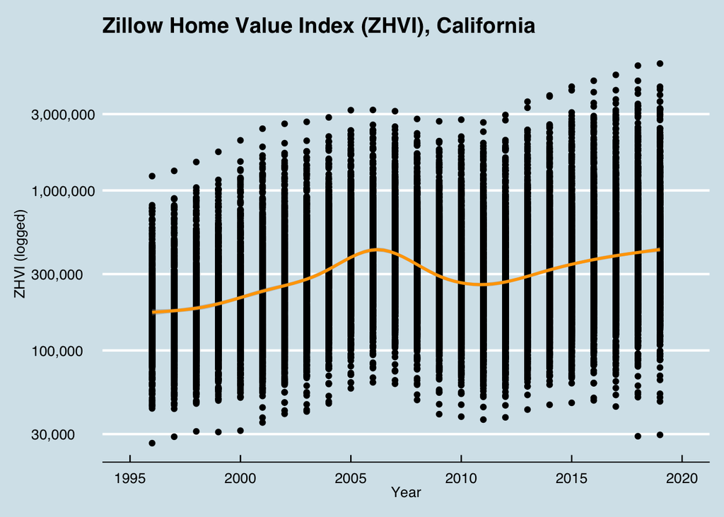

# Property Crime, 1995-2015

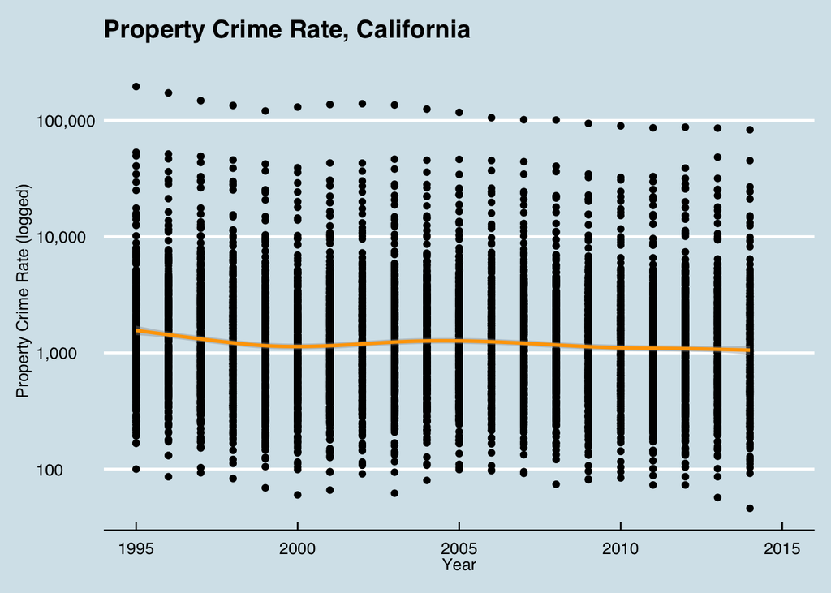

# Violent Crime, 1995-2015

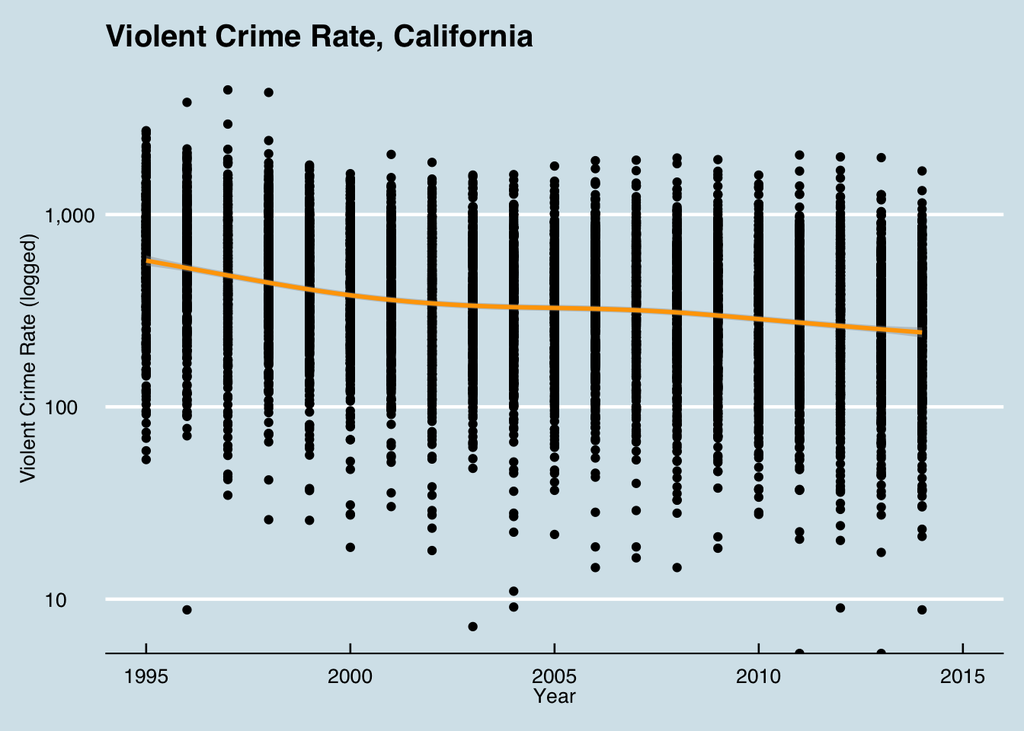

## 1.3 Adding Voter Data

Another potential explanation for differentiation between the core cities in California and suburban cities is partisanship. Although some research finds strong support for police among both Democrats and Republicans, others suggest that Republican-led cities devote more funding to police. Though not one of the independent variables of interest in my analysis, I include it as a control.

The data come from the CA Secretary of State’s Statewide Election Results: https://www.sos.ca.gov/elections/prior-elections/statewide-election-results/. I focus on presidential elections from 2000 to 2016. I cleaned data from the 5 elections and then merged with a file that has the GEOID for each place, which is a unique identifier provided by the Census.

```r
# loading voter data
load("data/vote_with_geo.RData")

# renaming city variable to match crime and housing data
vote_with_geo %<>% dplyr::rename(city_name = city)

# joining with crime and housing data
crime_zillow_vote <- left_join(x = crime_housing,
                               y= vote_with_geo,
                               by = c("year", "city_name"))
```

## 1.4 Now we are ready to merge with policing data

Now that I have crime data, housing price data, and voter data, I am ready to merge with the full policing dataset in order to begin analysis.

```r
# load policing data
load("data/policing_complete_lead.RData")

# turning year into a factor variable
dates <- unique(sort(crime_zillow_vote$year))
crime_zillow_vote$year <- factor(crime_zillow_vote$year, labels = dates,  ordered = T)

# now merging the policing data with crime
data_no_census <- left_join(x = policing_complete_lead,
                            y = crime_zillow_vote,
                            by = c("year",
                                   "city_name"))
# saving full dataset (minus Census data)
save(data_no_census,
     file = "data/data_no_census.RData")
```